# Feature Extraction (Parts of Speech)

[return to overview page]

Now we are going to extract another set of features from each statement. This will be the frequency with which various parts of speech occur.

# Packages

Again, I will start by loading relevant packages.

```r
# for rendering: eval=FALSE
library(tidyverse) # cleaning and visualization
library(quanteda) # text analysis
library(spacyr) # R wrapper for spaCy python package (used to extract parts of speech)
# thus, must have python installed for this package to actually work
# when using for first time, follow install instructions here: https://github.com/quanteda/spacyr
# remember to run RStudio as administrator, when installing; and then run:
spacy_install()
# I think could use this later, and not have to totally reinstall (if paths are all set right)
# spacy_initialize(model = "en") # english language model
```

# Load Data

Again, I will load the most recent version of the data files, which comes from Feature Extraction (Overview). (Note, we created a more recent object, recording various length metrics for each statement. However, we will not be using that object right now.)

```r
# this loads: stats_clean (a data-frame of out cleaned statements)
load("stats_clean.Rda")
```

# Parts of Speech

I am now going to go through each of the statements, and extract counts of the frequencies with which various parts of speech occur (e.g. the number of nouns, adjectives, pronouns, etc in each sentence). Previous research by Newman, Pennebaker, Berry, & Richards (2003) has found parts of speech to be a predictive feature in lie detection.

## Parts of Speech (Example)

I will again introduce this by walking through and example on a single sentence. The spacyr package (which is really a “wrapper” for a python text processing package) has an incredibly useful function called spacy_parse, which goes through a piece of text (e.g. a sentence), word by word, and identifies various characteristics of those words – including their part of speech.

We will use the sentence “The graduate student ate pasta for the fourth night in a row” as our example sentence. First, let’s create and print that sentence.

```r
# Create sentence
example_sent <- c("The graduate student ate pasta for the fourth night in a row.")
example_sent
```

```
## [1] "The graduate student ate pasta for the fourth night in a row."
```

### Extract Parts of Speech

Now, let’s run spacy_parse to extract the features from that sentence. As we can see, the sentence is taken apart, word by word. For each word in the sentence, a row is created. And then each word is mapped on to a part of speech. (See: in the tabular object below, the first column, “token”, has an entry for each word, and the second column, “pos”, has the part of speech each word has been mapped on to. So for example, we see the first word “The” is identified as DET, a determiner, the second word “graduate” is identified as a noun, and so on.)

```r
# Parse the sentence
parsed_ex <-
  spacy_parse(x = example_sent,
            pos = TRUE)

# Print in nicer format
data.frame(parsed_ex) %>%
  select(token,
         pos,
         everything())
```

| token | pos | doc_id | sentence_id | token_id | lemma | entity |
| --- | --- | --- | --- | --- | --- | --- |
| The | DET | text1 | 1 | 1 | the |  |
| graduate | NOUN | text1 | 1 | 2 | graduate |  |
| student | NOUN | text1 | 1 | 3 | student |  |
| ate | VERB | text1 | 1 | 4 | eat |  |
| pasta | NOUN | text1 | 1 | 5 | pasta |  |
| for | ADP | text1 | 1 | 6 | for |  |
| the | DET | text1 | 1 | 7 | the | TIME_B |
| fourth | ADJ | text1 | 1 | 8 | fourth | TIME_I |
| night | NOUN | text1 | 1 | 9 | night | TIME_I |
| in | ADP | text1 | 1 | 10 | in | TIME_I |

[output cut: 3 more lines]

### Count Each Part of Speech

For any given statement, we then want to count up the number of times each type of parts of speech occurs. I do this below for the example sentence. As we can see, our example sentence has 1 adjective, 2 adpositions (i.e. “ADP”, which counts prepositions, postpositions, and circumpositions), 3 determiners, 5 nouns, and 1 punctuation mark (the period).

```r
# count the number of each part of speech, and put back into each row = statement format
num_pos_ex <-
  parsed_ex %>%
  select(token,
         pos) %>%
  group_by(pos) %>%
  summarise(n = n()) %>%
  spread(key = pos,
         value = n,
         fill = 0) %>% # fill empty values with zero
  mutate(statement = example_sent) %>%
  select(statement,
         everything())
num_pos_ex
```

| statement | ADJ | ADP | DET | NOUN | PUNCT | VERB |
| --- | --- | --- | --- | --- | --- | --- |
| The graduate student ate pasta for the fourth night in a row. | 1 | 2 | 3 | 5 | 1 | 1 |

```r
# change the column names for the parts of speech colums, to more clearly identify them
for (i in 2:length(names(num_pos_ex))) {
  names(num_pos_ex)[i] <-
    paste("pos",
          names(num_pos_ex[i]),
          sep = "_")
}

# print the output
num_pos_ex
```

| statement | pos_ADJ | pos_ADP | pos_DET | pos_NOUN | pos_PUNCT | pos_VERB |
| --- | --- | --- | --- | --- | --- | --- |
| The graduate student ate pasta for the fourth night in a row. | 1 | 2 | 3 | 5 | 1 | 1 |

## Parts of Speech (Full Dataset)

Now, we are going to the do the same thing for all 5004 statements.

First, we are going to run through each sentence, decompose each word by word, and record the parts of speech that each word corresponds to.

```r
# for rendering: cache = TRUE

# initialize a data frame, which will have three columns:
  # - stat_id
  # - token
  # - part of speech
# and will be of the length: total num. statements * words per each statement

# first, count the total number of tokens
# (takes a minute, kind of redundant and dumb; but how I'm doing it for now)
num_words <- nrow(spacy_parse(stats_clean$statement))

# initialize that data frame
pos_long <-
    matrix(ncol = 3,
           nrow = num_words)
colnames(pos_long) <- c("stat_id", "token", "pos")

# now go through each statement
current_row = 0
start_time <- Sys.time() # store time at start of running
for (i in 1:nrow(stats_clean)) {
  # parse that statement, word by word
  stat_i <- spacy_parse(stats_clean$statement[i])
  for (k in 1:nrow(stat_i)) {
    current_row = current_row + 1
    # record stat_id for each word
    pos_long[current_row, 1] <- stats_clean$stat_id[i]
    # record each token
    pos_long[current_row, 2] <- stat_i$token[k]
    # record each token's corresponding part of speech
    pos_long[current_row, 3] <- stat_i$pos[k]
  }

}
total_time <- Sys.time() - start_time # store total time, just for reference

# Print total time it took to run
print("Total Run Time (as difference between start and stop)")
```

```
## [1] "Total Run Time (as difference between start and stop)"
```

```r
print(total_time)
```

```
## Time difference of 3.942621 mins
```

```r
# for rendering: cache = TRUE

# The key is that spacy_parse expects a TIF-compliant corpus data frame
# So, if I put the statemetns in a TIF-compliant object, we can parse that (and
# still keep track of the different "documents", here stat_id)
# TIF-compliant format is explained here: https://github.com/ropensci/tif

# Step 1. Organize statements in TIF-compliant way
test <-
  stats_clean %>%
  select(stat_id,
         statement) %>%
  rename(doc_id = stat_id,
         text = statement)

# Step 2. Parse the TIF-compliant object
start_time2 <- Sys.time()
spacy_parse(x = test,
            pos = TRUE)
```

| doc_id | sentence_id | token_id | token | lemma | pos | entity |
| --- | --- | --- | --- | --- | --- | --- |
| 2547 | 1 | 1 | nathan | nathan | INTJ |  |
| 2547 | 2 | 1 | and | and | CCONJ |  |
| 2547 | 2 | 2 | i | i | PRON |  |
| 2547 | 2 | 3 | met | meet | VERB |  |
| 2547 | 2 | 4 | while | while | ADP |  |
| 2547 | 2 | 5 | i | i | PRON |  |
| 2547 | 2 | 6 | was | be | VERB |  |
| 2547 | 2 | 7 | working | work | VERB |  |
| 2547 | 2 | 8 | as | as | ADP |  |
| 2547 | 2 | 9 | a | a | DET |  |

[output cut: 990 more lines]

```r
total_time2 <- Sys.time() - start_time2

# Print total time it took to run
print("Total Run Time (as difference between start and stop)")
```

```
## [1] "Total Run Time (as difference between start and stop)"
```

```r
print(total_time2)
```

```
## Time difference of 1.352147 mins
```

### Intermediate Resultant (“Long”) Object

Either way we do things, we end up with a very long tabublar object, where we now have a row for each word, rather than each statement. We want to convert that back to an tabular object, where every row is as a statement, and each column is a count, for the number of times, each of the types of parts of speech occurs (e.g. for each statment, we want a column that counts the number of adjectives, another column that counts the number of pronouns, and so on for each type of part of speech). That is what I create below. (Critically, we can do this, because for each word, we have a column storing the statement to which is corresponds. So it’s just a matter of re-grouping things.)

First, just for exposition, here is how the output object currently looks. (This object has 316,272 rows: that’s the total number of words and punctuation marks across out 5,004 statements.)

```r
# convert to data frame, for nicer presentation, and print
(pos_long <- data.frame(pos_long))
```

| stat_id | token | pos |
| --- | --- | --- |
| 2547 | nathan | INTJ |
| 2547 | and | CCONJ |
| 2547 | i | PRON |
| 2547 | met | VERB |
| 2547 | while | ADP |
| 2547 | i | PRON |
| 2547 | was | VERB |
| 2547 | working | VERB |
| 2547 | as | ADP |
| 2547 | a | DET |

[output cut: 990 more lines]

### Count Parts of Speech

Now, I am going to actually go through the process of counting the number of times each type of part of speech occurs in each statement, and re-organizing the structure of conver it back into a “wide” format, where each row represents a statement rather than a word. (Now, we see our data object has 5,004 rows, one for each statement.)

```r
# convert back to wide, where each row is a statement
stats_pos <-
  pos_long %>%
  group_by(stat_id,
           pos) %>%
  summarise(n = n()) %>%
  spread(key = pos,
         value = n,
         fill = 0) # fill empty values with zero

# change the column names for the parts of speech colums, to more clearly identify them
for (i in 2:length(names(stats_pos))) {
  names(stats_pos)[i] <-
    paste("pos",
          names(stats_pos[i]),
          sep = "_")
}

# print resulting data frame
stats_pos
```

| stat_id | pos_ADJ | pos_ADP | pos_ADV | pos_CCONJ | pos_DET | pos_INTJ | pos_NOUN | pos_NUM | pos_PART | pos_PRON | pos_PROPN | pos_PUNCT | pos_SPACE | pos_SYM | pos_VERB | pos_X |
| --- | --- | --- | --- | --- | --- | --- | --- | --- | --- | --- | --- | --- | --- | --- | --- | --- |
| 1 | 7 | 8 | 8 | 3 | 6 | 0 | 12 | 0 | 5 | 7 | 0 | 7 | 0 | 0 | 15 | 0 |
| 10 | 3 | 4 | 0 | 3 | 4 | 0 | 7 | 0 | 4 | 8 | 0 | 9 | 0 | 0 | 13 | 0 |
| 100 | 3 | 8 | 6 | 6 | 4 | 0 | 7 | 0 | 3 | 16 | 0 | 3 | 0 | 0 | 17 | 0 |
| 1000 | 4 | 3 | 7 | 0 | 5 | 0 | 13 | 1 | 1 | 6 | 0 | 4 | 3 | 0 | 10 | 0 |
| 1001 | 5 | 8 | 4 | 2 | 5 | 0 | 10 | 2 | 0 | 4 | 0 | 8 | 0 | 1 | 8 | 0 |
| 1002 | 5 | 4 | 3 | 4 | 0 | 0 | 8 | 2 | 4 | 7 | 0 | 6 | 0 | 0 | 13 | 0 |
| 1003 | 3 | 5 | 2 | 4 | 2 | 0 | 12 | 0 | 1 | 5 | 0 | 4 | 2 | 0 | 11 | 0 |
| 1004 | 2 | 6 | 7 | 2 | 5 | 0 | 22 | 2 | 2 | 8 | 0 | 17 | 0 | 0 | 10 | 0 |
| 1005 | 6 | 2 | 3 | 2 | 4 | 0 | 6 | 0 | 1 | 6 | 0 | 4 | 0 | 0 | 9 | 0 |
| 1006 | 7 | 1 | 2 | 3 | 4 | 0 | 10 | 0 | 5 | 5 | 0 | 4 | 0 | 0 | 11 | 0 |

[output cut: 990 more lines]

## Parts of Speech (Results)

Now, let’s take a peak out how the different parts of speech are distributed across out statements. Specifically, let’s look at how frequency each type of part of speech occurs across all statements.

### Summary Statistics

First, let’s look at some summary statistics. In the table below, for each part of speech, I computed the median number of times it occured across all statements, as well as some distributional information (e.g. percentile_95 indicates the 95th percentile for that part of speech). And then I sorted this list by the parts of speech that occured most frequently (as measured by median number of occurences). As we can see, the part of speech that occurs most frequently across our statemetns are verbs (with a median of 12 occurences), followed by nouns and then pronouns.

```r
stats_pos %>%
  gather(key = part_of_speech,
         value = n,
         pos_ADJ:pos_X) %>%
  group_by(part_of_speech) %>%
  summarise(median = median(n),
         percentile_5 = quantile(n, probs = c(0.05)),
         percentile_10 = quantile(n, probs = c(0.10)),
         percentile_25 = quantile(n, probs = c(0.25)),
         percentile_75 = quantile(n, probs = c(0.75)),
         percentile_90 = quantile(n, probs = c(0.90)),
         percentile_95 = quantile(n, probs = c(0.95))) %>%
  arrange(desc(median))
```

| part_of_speech | median | percentile_5 | percentile_10 | percentile_25 | percentile_75 | percentile_90 | percentile_95 |
| --- | --- | --- | --- | --- | --- | --- | --- |
| pos_VERB | 12 | 8 | 8 | 10 | 15 | 18 | 21 |
| pos_NOUN | 9 | 5 | 6 | 7 | 12 | 15 | 18 |
| pos_PRON | 7 | 3 | 4 | 5 | 9 | 11 | 13 |
| pos_ADP | 6 | 2 | 3 | 4 | 8 | 10 | 11 |
| pos_ADJ | 5 | 2 | 3 | 4 | 7 | 9 | 11 |
| pos_ADV | 5 | 1 | 2 | 3 | 7 | 9 | 10 |
| pos_PUNCT | 5 | 3 | 3 | 4 | 6 | 8 | 10 |
| pos_DET | 4 | 1 | 1 | 2 | 5 | 7 | 8 |
| pos_CCONJ | 3 | 1 | 1 | 2 | 4 | 5 | 6 |
| pos_PART | 2 | 0 | 0 | 1 | 3 | 4 | 5 |

[output cut: 6 more lines]

### Distributions

And now let’s visualize the distribution of the frequency with which various parts of speech occurred. (Note: I eliminated any statements where a part of speech occured more than 20 times, as this is well above the 95th percentile for almost all types of parts of speech; and including the few statements with an extreme number of parts of speech would distort the x-axis to the extant that it would become hard to view.) As we can see, some parts of speech occur much more frequency and with more variabilit than others (e.g. adjective usually occur around 5 times in these statements, but the model number of times than an interjection occurs is zero in these statements).

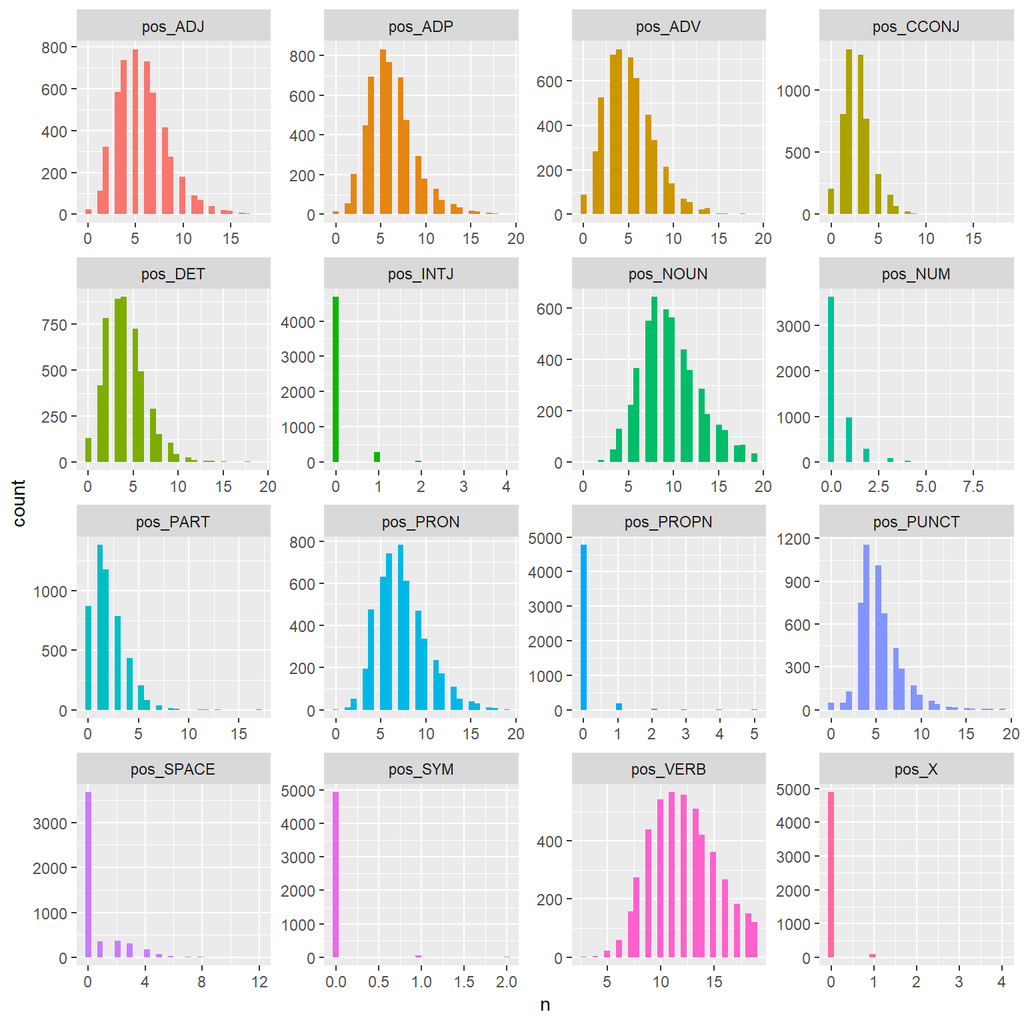

```r
stats_pos %>%
  gather(key = part_of_speech,
         value = n,
         pos_ADJ:pos_X) %>%
  filter(n < 20) %>%
  ggplot(aes(x = n,
             fill = part_of_speech)) +
    geom_histogram() +
    facet_wrap( ~part_of_speech,
                ncol = 4,
                scales = "free") +
  guides(fill=FALSE) # remove legend
```

# Save

Finally, let’s save the new data object we created, which for each statement records the number of times various parts of speech occurred.

```r
save(stats_pos,
     file = "stats_pos.Rda")

# now remove stats_clean from global environment (to avoid later confusion)
rm(stats_clean)
```

# Render

(This section is just for me. And is a note on how to render this to html format, given the use of spacyr complicates the process a tiny bit).

- render from the R console (remember to setwd() to correct wd)
- use the following command to render from console: rmarkdown::render(“hld_FEATURE_pos.Rmd”)
- for chunks that are difficult to run (i.e. spacy_install), set the chunk option at the top to false (i.e. {r, evale = FALSE}), and run the rest of the script without it (this is not great for reproducibility, but worse I would argue is not being able to render the document at all; all alternatives are even less reproducible)
- thus, you are rendering from the current session; good discusison here: https://stackoverflow.com/questions/34591487/difference-compile-pdf-button-in-rstudio-vs-knit-and-knit2pdf/48494678

# Citations

- Newman, M. L., Pennebaker, J. W., Berry, D. S., & Richards, J. M. (2003). Lying words: Predicting deception from linguistic styles. Personality and social psychology bulletin, 29(5), 665-675.